# DEG Visualization SIG30

EYW

2026-07-24

Visualizes the DEG results from `deg_analysis_SIG30.Rmd` (`analysis_outs/res_targets_SIG30.csv`): clustered sample-correlation heatmaps restricted to DEGs (built two ways — normalized-count expression and the z-scored-vs-control matrix from `processing/zscore_processing_SIG30.Rmd`), a knockdown-validation bar plot of each target gene’s own expression across conditions, and a compact target-gene x KO-condition LFC heatmap annotated for significance.

```r
library(tidyverse)
```

```r
library(ggplot2)
library(ggthemes)
library(patchwork)
library(RColorBrewer)
library(pheatmap)
library(tidyplots)
knitr::opts_chunk$set(echo = TRUE, warning = FALSE, message = FALSE)

source("../../functions/r_custom/plotting_fxns.R")
theme_set(theme_Publication())
```

### Import Data

`norm_counts_matrix_SIG30.csv` (DESeq2 size-factor-normalized counts) and `zscore_matrix_SIG30.csv` (per-gene z-score vs. `control` mean/SD) are both produced by `processing/zscore_processing_SIG30.Rmd`, already indexed by gene symbol with `sample_ID`-matching column names — no need to rebuild a DESeq2 model here.

```r
metadata <- read_csv("../../processing_outs/processed_metadata_SIG30.csv")

norm_counts <- read.csv("../../processing_outs/norm_counts_matrix_SIG30.csv", row.names = 1, check.names = FALSE)
zscore      <- read.csv("../../processing_outs/zscore_matrix_SIG30.csv", row.names = 1, check.names = FALSE)

res_targets <- read_csv("../../analysis_outs/res_targets_SIG30.csv")
```

```r
# set metadata factors (control = reference level), mirroring deg_analysis_SIG30.Rmd
metaDF <- metadata %>%
  mutate(
    replicate = factor(replicate),
    target    = factor(target, levels = c("control", sort(setdiff(unique(target), "control"))))
  ) %>%
  as.data.frame()
rownames(metaDF) <- metaDF$sample_ID

norm_counts <- norm_counts[, rownames(metaDF)]
zscore      <- zscore[, rownames(metaDF)]
```

### DEG gene set

Union of genes significant (padj < 0.01) vs. `control` in at least one target, used as the gene set for both correlation heatmaps below.

```r
finite_rows <- function(mat) rownames(mat)[apply(mat, 1, function(x) all(is.finite(x)))]

deg_genes <- res_targets %>%
  filter(padj < 0.01) %>%
  distinct(gene) %>%
  pull(gene) %>%
  intersect(rownames(norm_counts)) %>%
  # zscore is undefined (NA/Inf) for genes with zero control-group variance; drop those
  intersect(finite_rows(zscore))

length(deg_genes)
```

```
## [1] 4202
```

```r
mk_pal <- function(n) colorRampPalette(tableau_color_pal("Tableau 10")(10))(n)
target_colors <- setNames(mk_pal(nlevels(metaDF$target)), levels(metaDF$target))
ann_col <- data.frame(target = metaDF$target, row.names = rownames(metaDF))
ann_colors <- list(target = target_colors)
```

### Sample correlation heatmap: normalized-count expression of DEGs

Pearson correlation between samples computed on log2(normalized count + 1), restricted to the DEG gene set; hierarchically clustered, with a `target` color bar.

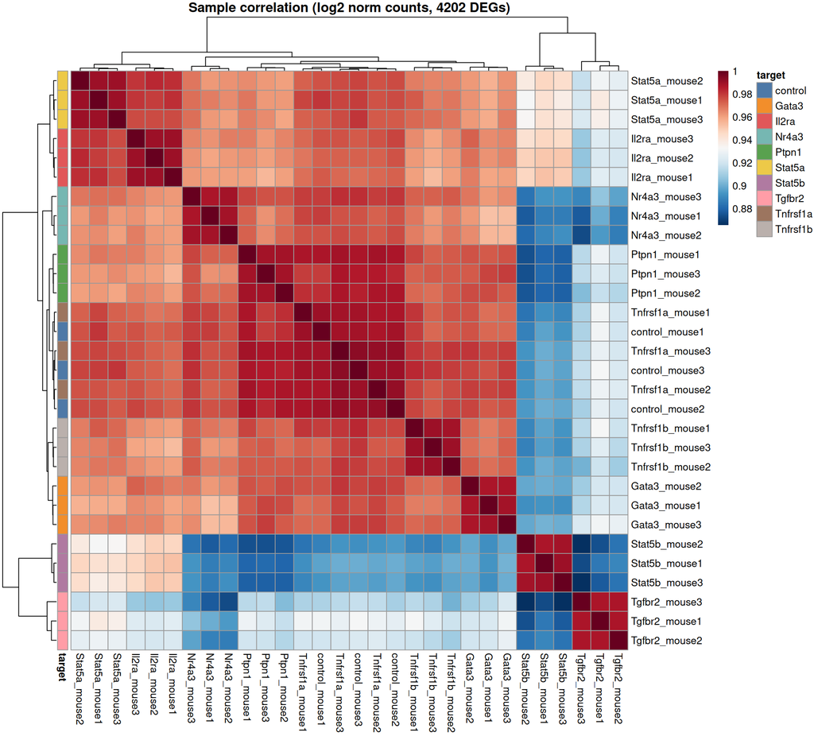

```r
expr_deg <- log2(norm_counts[deg_genes, ] + 1)
cor_expr <- cor(expr_deg, method = "pearson")

pheatmap(cor_expr,
         color = colorRampPalette(rev(brewer.pal(11, "RdBu")))(100),
         annotation_row = ann_col,
         annotation_colors = ann_colors,
         main = paste0("Sample correlation (log2 norm counts, ", length(deg_genes), " DEGs)"))
```

### Sample correlation heatmap: z-scored (pseudo-LFC) DEGs

Pearson correlation between samples computed on the `zscore_matrix_SIG30.csv` values (each gene z-scored against the `control` mean/SD), restricted to the DEG gene set. This asks whether samples share a *deviation-from-control pattern* rather than raw expression level.

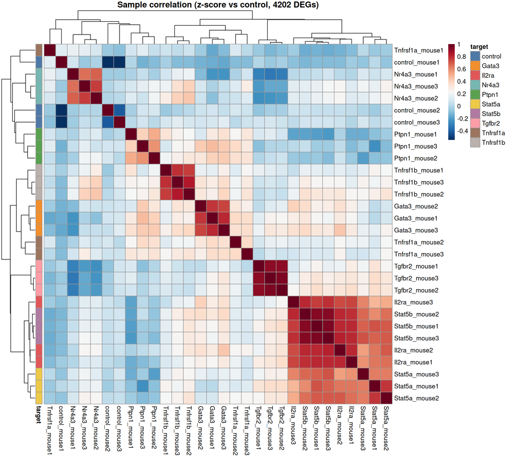

```r
lfc_deg <- zscore[deg_genes, ]
cor_lfc <- cor(lfc_deg, method = "pearson")

pheatmap(cor_lfc,
         color = colorRampPalette(rev(brewer.pal(11, "RdBu")))(100),
         annotation_row = ann_col,
         annotation_colors = ann_colors,
         main = paste0("Sample correlation (z-score vs control, ", length(deg_genes), " DEGs)"))
```

### Target-gene knockdown validation: expression bar plot

```r
target_genes <- levels(metaDF$target) %>% setdiff("control")

gene_expr <- norm_counts[rownames(norm_counts) %in% target_genes, , drop = FALSE] %>%
  rownames_to_column("gene") %>%
  pivot_longer(-gene, names_to = "sample_ID", values_to = "expr") %>%
  left_join(metaDF %>% dplyr::select(sample_ID, target), by = "sample_ID") %>%
  mutate(target = as.character(target)) %>%
  filter(target == gene | target == "control") %>%
  mutate(is_self = target == gene)
```

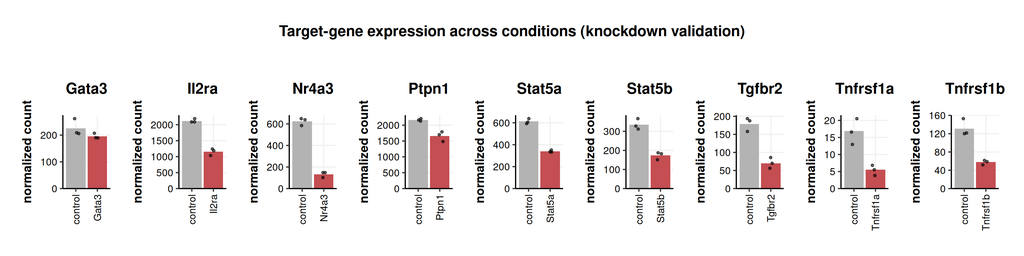

```r
plot_list <- gene_expr %>%
  split(.$gene) %>%
  imap(function(df, gene_name) {
    df %>%
      mutate(target = factor(target, levels = c("control", gene_name))) %>%
      ggplot(aes(x = target, y = expr)) +
      stat_summary(aes(fill = is_self), fun = mean, geom = "col") +
      geom_jitter(width = 0.15, size = 1, alpha = 0.6) +
      scale_fill_manual(values = c(`TRUE` = "#C44E52", `FALSE` = "grey70"), guide = "none") +
      theme(axis.text.x = element_text(angle = 90, vjust = 0.5, hjust = 1)) +
      labs(x = NULL, y = "normalized count", title = gene_name) +
      scale_y_continuous(expand = expansion(mult = c(0, 0.05)), limits = c(0, NA))
  })

wrap_plots(plot_list, ncol = 9) +
  plot_annotation(title = "Target-gene expression across conditions (knockdown validation)")
```

```r
ggsave("../../analysis_outs/target_lfc_barplots_SIG30.pdf")
```

### Target-gene x KO-condition LFC heatmap

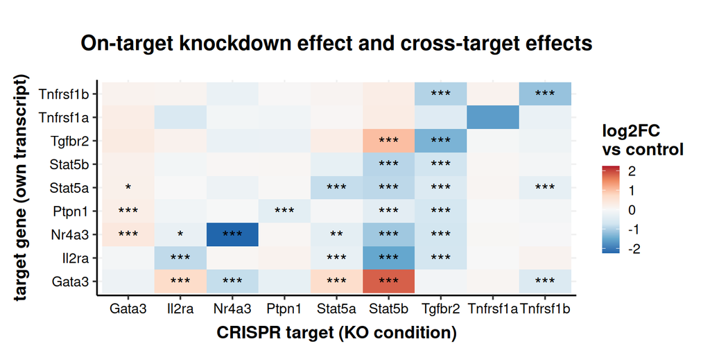

```r
target_lfc <- res_targets %>%
  filter(gene %in% target_genes, target %in% target_genes) %>%
  mutate(
    gene   = factor(gene, levels = target_genes),
    target = factor(target, levels = target_genes),
    sig = case_when(
      padj < 0.001 ~ "***",
      padj < 0.01  ~ "**",
      padj < 0.05  ~ "*",
      TRUE         ~ ""
    )
  )

target_lfc %>%
  ggplot(aes(x = target, y = gene, fill = log2FoldChange)) +
  geom_tile() +
  geom_text(aes(label = sig), size = 5, vjust = 0.7) +
  scale_fill_distiller(palette = "RdBu", limits = c(-1, 1) * max(abs(target_lfc$log2FoldChange))) +
  labs(x = "CRISPR target (KO condition)", y = "target gene (own transcript)",
       fill = "log2FC\nvs control",
       title = "On-target knockdown effect and cross-target effects")
```

```r
ggsave("../../analysis_outs/target_lfc_heatmap_SIG30.pdf")
```